# Quantitative notions of relevance: Data analysis

Author

Alex Warstadt, Omar Aghar & Michael Franke

First load required packages and set some global parameters.

```r
library(tidyverse)
library(brms)
library(tidyboot)
library(tidyjson)
library(patchwork)
library(GGally)
library(cowplot)
library(BayesFactor)
library(aida)   # custom helpers: https://github.com/michael-franke/aida-package
library(faintr) # custom helpers: https://michael-franke.github.io/faintr/index.html
library(cspplot) # custom styles: https://github.com/CogSciPrag/cspplot
library(ordbetareg) # for ordered beta-regression
library(cmdstanr)

##################################################

# these options help Stan run faster
options(mc.cores = parallel::detectCores(),
        brms.backend = "cmdstanr")

# use the CSP-theme for plotting
theme_set(theme_csp())

# global color scheme from CSP
project_colors = cspplot::list_colors() |> pull(hex)

# setting theme colors globally
scale_colour_discrete <- function(...) {
  scale_colour_manual(..., values = project_colors)
}
scale_fill_discrete <- function(...) {
  scale_fill_manual(..., values = project_colors)
}

##################################################

rerun_models <- FALSE

Lambert_test <- function(loo_comp) {
  1 - pnorm(-loo_comp[2,1], loo_comp[2,2])
}
```

# Read & massage the data

The data is pre-processed (using Python). We load it and rearrange for convenience.

```r
d <- read_csv("../results/round_2.0/results_preprocessed.csv") |>
  # drop column with numbers
  select(-`...1`) |>
  # set "non-answers" to AnswerPolarity "positive"
  mutate(AnswerPolarity = ifelse(
    AnswerCertainty == "non_answer",
    "positive",
    AnswerPolarity)) |>
  # casting into factor
  mutate(
    group = factor(group, levels = c("relevant", "helpful")),
    ContextType = factor(ContextType,
                         levels = c("negative", "neutral", "positive")),
    AnswerPolarity = factor(AnswerPolarity,
                            levels = c("positive", "negative")),
    AnswerCertainty = factor(AnswerCertainty,
                             levels = c("non_answer", "low_certainty",
                                        "high_certainty", "exhaustive"))
  )
```

# Data exclusion

We exclude all data from participants who:

- score less than perfect on all attention checks,
- scored less than 0.5 on reasoning tasks, or
- has task-sensitivity of not more than 0.75

Task sensitivity is the proportion of critical trials, excluding non-answer trials, in which the change between prior and posterior rating was bigger than 0.05 or there was a non-zero change in confidence rating.

We first add the task-sensitivity score:

```r
d <- d |> as_tibble() |>
  mutate(answer_class  = ifelse(AnswerCertainty != "non_answer", "answer", "non_answer"),
         belief_change = abs(prior_sliderResponse - posterior_sliderResponse) >= 0.05 |                                     prior_confidence != posterior_confidence,
         deviant = case_when(answer_class == "answer" ~ !belief_change,
                             answer_class != "answer" ~  FALSE)
         ) |>
  group_by(submission_id) |>
  mutate(task_sensitivity = 1- sum(deviant) / sum(answer_class == "answer")) |>
  select(- answer_class, - belief_change, - deviant)
```

# Exploring the effect of the experimental factors

The experiment had the following factors:

- `group`: whether a participant rated the ‘helpfulness’ or the ‘relevance’ of the answer (between-subjects variable)
- `ContextType`: whether the context made a ‘no’ or a ‘yes’ answer more likely /a priori/ or whether it was neutral (within-subjects)
- `AnswerCertainty`: how much information the answer provides towards a fully resolving answer (within-subjects)
- `AnswerPolarity`: whether the answer suggests or implies a ‘no’ or a ‘yes’ answer (within-subjects)
  - ‘non-answers’ are treated as ‘positive’ for technical purposes, but this does not influence relevant analyses

In the following, we first check whether these experimental manipulations worked as intended.

## Sanity-checking whether the manipulations worked as intended

### Effects of `ContextType` on prior and prior confidence

To check whether the `ContextType` manipulation worked, we compare how participants rated the prior probability of a ‘yes’ answer under each level of the `ContextType` variable. Concretely, we expect this order of prior ratings for the levels of `ContextType`: negative < neutral < positive. Although we have no specific hypotheses or sanity-checking questions regarding the confidence ratings, let’s also scrutinize the confidence ratings that participants gave with their prior ratings.

#### Prior ratings as a function of `ContextType`

Here is a first plot addressing the question after an effect of `ContextType` on participants prior ratings.

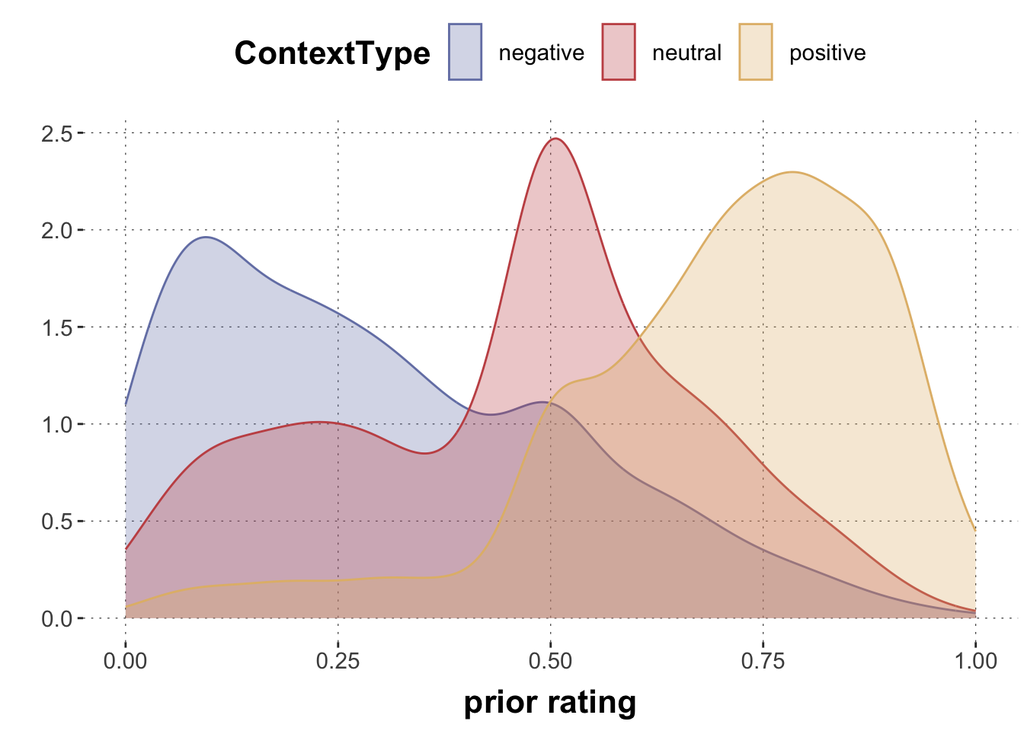

```r
d |> ggplot(aes(x = prior_sliderResponse, color = ContextType, fill = ContextType)) +
  geom_density(alpha = 0.3) +
  xlab("prior rating") +
  ylab("")
```

We dive deeper by fitting a regression model, predicting prior ratings in terms of the `ContextType`. Since participants have not seen the answer when they rate the prior probability of a ‘yes’ answer, `ContextType` is the only fixed effect we should include here. The model also includes the maximal RE structure. We use the `ordbetareg` package for (slider-data appropriate) zero-one inflated ordinal beta regression.

```r
if (rerun_models) {
  fit_contextType_SC <- ordbetareg::ordbetareg(
    prior_sliderResponse ~ ContextType +
      (1 + ContextType | StimID) +
      (1 + ContextType | submission_id),
    data = d,
    iter = 3000 # ensure sufficent ESS
  )
  saveRDS(fit_contextType_SC, "cachedModels-round2/fit_contextType_SC.Rds")
} else{
  fit_contextType_SC <- readRDS("cachedModels-round2/fit_contextType_SC.Rds")
}
```

Our assumption is that prior ratings are higher in contexts classified as ‘neutral’ than in ‘negative’ contexts, and yet higher in ‘positive’ contexts. We use the `faintr` package to extract information on these directed comparisons.

```r
ContextType_SC_negVSneu <-
  compare_groups(
    fit_contextType_SC,
    lower = ContextType == "negative",
    higher = ContextType == "neutral"
  )
ContextType_SC_neuVSpos <-
  compare_groups(
    fit_contextType_SC,
    lower = ContextType == "neutral",
    higher = ContextType == "positive"
  )
```

#### Prior confidence as a function of `ContextType`

Here is a visualization of the effect of `ContextType` on participants’ confidence in their prior ratings.

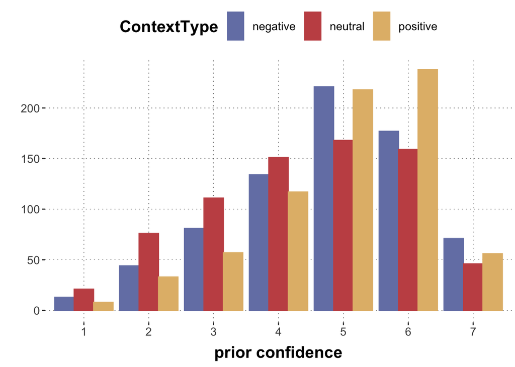

```r
d |> mutate(prior_confidence = factor(prior_confidence, levels = 1:7)) |>
  ggplot(aes(x = prior_confidence, color = ContextType, fill = ContextType)) +
  geom_histogram(position = "dodge", stat='count') +
  xlab("prior confidence") +
  ylab("")
```

To scrutinize the effect of `ContextType` on participants expressed confidence in their prior ratings, we use a ordered-logit regression (since prior confidence ratings are from a rating scale).

```r
if (rerun_models) {
  fit_contextType_SC_conf <- brm(
    prior_confidence ~ ContextType +
      (1 + ContextType | StimID) +
      (1 + ContextType | submission_id),
    data = d,
    family = cumulative(),
    iter = 3000
  )
  saveRDS(fit_contextType_SC_conf, "cachedModels-round2/fit_contextType_SC_conf.Rds")
} else{
  fit_contextType_SC_conf <- readRDS("cachedModels-round2/fit_contextType_SC_conf.Rds")
}
```

```r
ContextType_SC_neuVSneg_conf <-
  compare_groups(
    fit_contextType_SC_conf,
    lower = ContextType == "neutral",
    higher = ContextType == "negative"
  )
ContextType_SC_negVSpos_conf <-
  compare_groups(
    fit_contextType_SC_conf,
    lower = ContextType == "negative",
    higher = ContextType == "positive"
  )
ContextType_SC_neuVSpos_conf <-
  compare_groups(
    fit_contextType_SC_conf,
    lower = ContextType == "neutral",
    higher = ContextType == "positive"
  )
```

#### Results

The results of these comparisons are summarized here:

| comparison | measure | posterior | 95% HDI (low) | 95% HDI (high) |
| --- | --- | --- | --- | --- |
| negative < neutral | prior | 0.9973333 | 0.292325 | 1.134670 |
| neutral < positive | prior | 0.9998333 | 0.507056 | 1.558420 |
| neutral < negative | prior-confidence | 0.9891667 | 0.131985 | 1.284680 |
| negative < positive | prior-confidence | 0.7971667 | -0.505641 | 1.205520 |
| neutral < positive | prior-confidence | 0.9958333 | 0.347629 | 1.798132 |

### Effects of `AnswerPolarity` and `AnswerCertainty` on `beliefChange`

We can define `beliefChange` as the difference between posterior and prior *in the direction expected from the answer’s polarity* (posterior belief in ‘yes’ answer increases for a ‘positive’ answer when compared with the prior rating, but it decreases for ‘negative’ answers). (Careful: we ignore non-answers (which are categorized as “positive” for technical convenience only).) If our manipulation worked, we expect the following for both ‘positive’ and ‘negative’ polarity:

1. `beliefChange` is > 0
2. `beliefChange` is lower for ‘low certainty’ than for ‘high certainty’ than for ‘exhaustive’

Here is a plot visually addressing these issues:

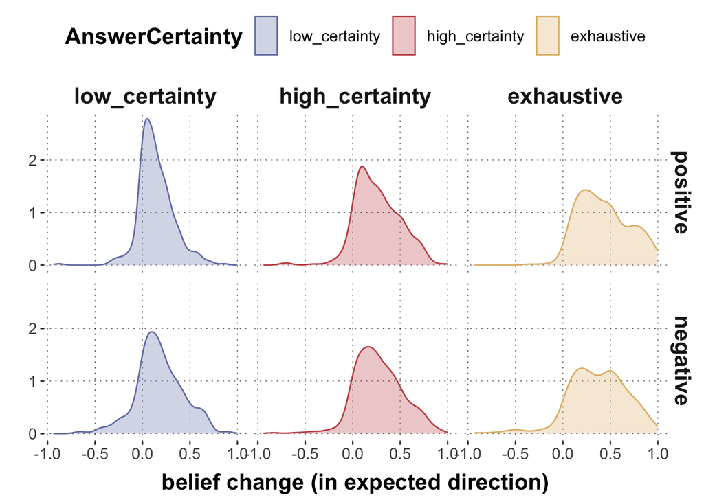

```r
d |> filter(AnswerCertainty != "non_answer") |>
  mutate(beliefChange = posterior_sliderResponse - prior_sliderResponse,
         beliefChange = ifelse(AnswerPolarity == "positive", beliefChange, - beliefChange)) |>
  ggplot(aes(x = beliefChange, color = AnswerCertainty, fill = AnswerCertainty)) +
  geom_density(alpha = 0.3) +
  facet_grid(AnswerPolarity ~ AnswerCertainty) +
  xlab("belief change (in expected direction)") +
  ylab("") + theme_aida()
```

#### `beliefChange` is positive

To address the first issue, whether `beliefChange` is positive for both types of polartiy, we first regress `beliefChange` against the full list of potentially relevant factors, including plausible RE structures. Notice that at the time of answer the questions related to the posterior, participants have not yet seen the question after relevance or helpfulness, so that factor `group` should be ommitted.

```r
# TODO: strictly speaking, this is data from a bounded scale; different regression model would be appropiate
if (rerun_models) {
  fit_answer_SC <- brm(
    formula = beliefChange ~ ContextType * AnswerCertainty * AnswerPolarity +
      (1 + ContextType + AnswerCertainty + AnswerPolarity | StimID) +
      (1 + ContextType + AnswerCertainty + AnswerPolarity | submission_id),
    data = d |> filter(AnswerCertainty != "non_answer") |>
      mutate(beliefChange = posterior_sliderResponse - prior_sliderResponse,
             beliefChange = ifelse(AnswerPolarity == "positive", beliefChange, - beliefChange))
  )
  saveRDS(fit_answer_SC, "cachedModels-round2/fit_answer_SC.Rds")
} else{
  fit_answer_SC <- readRDS("cachedModels-round2/fit_answer_SC.Rds")
}
```

We check if inferred cell means are credibly bigger than zero, for all six relevant design cells (facets in the plot above).

```r
# 1. Check if belief change in each cell is bigger than zero
cellDraws_answers <- tibble(
  low_pos  = extract_cell_draws(fit_answer_SC, AnswerCertainty == "low_certainty"  & AnswerPolarity == "positive", "low_pos")$low_pos,
  high_pos = extract_cell_draws(fit_answer_SC, AnswerCertainty == "high_certainty" & AnswerPolarity == "positive", "high_pos")$high_pos,
  exh_pos  = extract_cell_draws(fit_answer_SC, AnswerCertainty == "exhaustive"     & AnswerPolarity == "positive", "exh_pos")$exh_pos,
  low_neg  = extract_cell_draws(fit_answer_SC, AnswerCertainty == "low_certainty"  & AnswerPolarity == "negative", "low_neg")$low_neg,
  high_neg = extract_cell_draws(fit_answer_SC, AnswerCertainty == "high_certainty" & AnswerPolarity == "negative", "high_neg")$high_neg,
  exh_neg  = extract_cell_draws(fit_answer_SC, AnswerCertainty == "exhaustive"     & AnswerPolarity == "negative", "exh_neg")$exh_neg
)

# all posterior 95% HDIs are wayabove 0
apply( cellDraws_answers |> as.matrix(), MARGIN = 2, aida::summarize_sample_vector)
```

```
$low_pos
# A tibble: 1 × 4
  Parameter `|95%`  mean `95%|`
  <chr>      <dbl> <dbl>  <dbl>
1 ""        0.0861 0.131  0.176

$high_pos
# A tibble: 1 × 4
  Parameter `|95%`  mean `95%|`
  <chr>      <dbl> <dbl>  <dbl>
1 ""         0.202 0.257  0.306

$exh_pos
# A tibble: 1 × 4
  Parameter `|95%`  mean `95%|`
  <chr>      <dbl> <dbl>  <dbl>
1 ""         0.396 0.447  0.499

$low_neg
# A tibble: 1 × 4
  Parameter `|95%`  mean `95%|`
  <chr>      <dbl> <dbl>  <dbl>
1 ""         0.105 0.177  0.250

$high_neg
# A tibble: 1 × 4
  Parameter `|95%`  mean `95%|`
  <chr>      <dbl> <dbl>  <dbl>
1 ""         0.206 0.282  0.356

$exh_neg
# A tibble: 1 × 4
  Parameter `|95%`  mean `95%|`
  <chr>      <dbl> <dbl>  <dbl>
1 ""         0.301 0.363  0.428
```

```r
# posterior probability of mean bigger 0 for each cell is almost 1 everywhere
apply(as.matrix(cellDraws_answers), MARGIN=2, function(x) {mean(x>0)})
```

```
 low_pos high_pos  exh_pos  low_neg high_neg  exh_neg
       1        1        1        1        1        1
```

These results suggest that there is little reason to doubt that the belief changes induces by the answers -as per the experimentally intended manipulation- went in the right direction in all cases.

#### `beliefChange` increases with more informative answers

Finally, we investigate whether `beliefChange` increases with more informative answers, using the same regression model as before.

```r
AnswerPolarity_main <- compare_groups(
  fit_answer_SC,
  lower = AnswerPolarity == "positive",
  higher  = AnswerPolarity == "negative"
)

AnswerCertainty_lowVShigh <- compare_groups(
  fit_answer_SC,
  lower   = AnswerCertainty == "low_certainty",
  higher  = AnswerCertainty == "high_certainty"
)

AnswerCertainty_highVSexh <- compare_groups(
  fit_answer_SC,
  lower   = AnswerCertainty == "high_certainty",
  higher  = AnswerCertainty == "exhaustive"
)
```

| comparison | measure | posterior | 95%HDI (low) | 95%HDI (high) |
| --- | --- | --- | --- | --- |
| pos vs neg polarity | belief change | 0.44000 | -0.0708233 | 0.0726474 |
| low vs high certainty | belief change | 1.00000 | 0.0671545 | 0.1705422 |
| high certain vs exh | belief change | 0.99925 | 0.0713969 | 0.2049482 |

We see no indication of a main effect of polarity, but find support for the idea that our manipulation of `AnswerCertainty` induced gradually larger belief changes. I sum, it seems that the stimuli were adequately created to implement the intended manipulation in the variables `AnswerCertainty` and `AnswerPolarity`.

## Predicting relevance in terms of the experimental factors

We want to explore how relevance ratings depend on the experimental manipulations. First, we check whether the `group` variable (the trigger word: ‘helpful’ vs ‘relevant’) is important. If not, we can simplify subsequent analyses.

Next, we investigate the effects variables like `AnswerCertainty` `AnswerPolarity` etc. on relevance ratings.

### Can we gloss over the different trigger words?

To simplify analyses, it would be helpful to know whether we can gloss over the `group` manipulation. So, does it matter whether participants were asked to rate *relevance* or *helpfulness*?

To further investigate this contrast, we may fit two beta regression models, one with and one without the `group` factor. We check whether there is a credible main effect of `group` in the full model and a significant difference in LOO score when comparing these models. The former is for fun, the latter determines whether we should lump trigger words together.

```r
if (rerun_models) {

  # TODO too small ESS
  fit_with_group_ordBeta <- ordbetareg::ordbetareg(
    # must omitt interactions in the REs to ensure proper fit
    formula = relevance_sliderResponse ~ group * ContextType * AnswerCertainty * AnswerPolarity +
      (1 + group + ContextType + AnswerCertainty + AnswerPolarity || StimID) +
      (1 + ContextType + AnswerCertainty + AnswerPolarity || submission_id),
    data = d,
    # set this prior, otherwise there are errors
    coef_prior_SD = 5,
    save_pars = save_pars(all=T)
  )

  fit_without_group_ordBeta <- ordbetareg::ordbetareg(
    relevance_sliderResponse ~ ContextType * AnswerCertainty * AnswerPolarity +
      (1 + ContextType + AnswerCertainty + AnswerPolarity || StimID) +
      (1 + ContextType + AnswerCertainty + AnswerPolarity || submission_id),
    data = d,
    coef_prior_SD = 5,
    save_pars = save_pars(all=TRUE)
  )
  saveRDS(fit_with_group_ordBeta, "cachedModels-round2/fit_with_group_ordBeta.Rds")
  saveRDS(fit_without_group_ordBeta, "cachedModels-round2/fit_without_group_ordBeta.Rds")
} else {
  fit_with_group_ordBeta    <- read_rds("cachedModels-round2/fit_with_group_ordBeta.Rds")
  fit_without_group_ordBeta <- read_rds("cachedModels-round2/fit_without_group_ordBeta.Rds")
}
```

We inspect whether there is a main effect of `group` in the full model:

```r
# main effect of "group" ?
group_main <- compare_groups(
  fit_with_group_ordBeta,
  higher = group == "relevant",
  lower  = group == "helpful"
)
print(group_main)
```

```
Outcome of comparing groups:
 * higher:  group == "relevant"
 * lower:   group == "helpful"
Mean 'higher - lower':  0.2069
95% HDI:  [ 0.07441 ; 0.3409 ]
P('higher - lower' > 0):  0.9978
Posterior odds:  443.4
```

The posterior for the main factor of `group` is credibly different from zero.

But that is not the best criterion to decide whether the `group` distinction is relevant for predictions. We there also compare models with LOO cross-validation:

```r
if (rerun_models) {
  loo_comp <- loo::loo_compare(
    list("w/__group" = loo(fit_with_group_ordBeta),
                           # moment_match = TRUE,
                           # reloo = TRUE),
         "w/o_group" = loo(fit_without_group_ordBeta)))
                           # moment_match = TRUE,
                           # reloo = TRUE)))
  saveRDS(loo_comp, "cachedModels-round2/loo_comp_groups.Rds")
} else {
  loo_comp = read_rds("cachedModels-round2/loo_comp_groups.Rds")
}
loo_comp
```

```
          elpd_diff se_diff
w/o_group  0.0       0.0
w/__group -2.8       6.9
```

```r
Lambert_test(loo_comp)
```

```
[1] 0.9999762
```

It appears that, when comparing these models with REs, the lesioned model is numerically even slightly better than the model including `group`, but not by a substantial margin. From a predictive point of view, including `group` does not add substantial value. We will therefore lump trigger words together in the following.

### Effect of `AnswerPolarity`, `AnswerCertainty` and `ContextType` on relevance ratings

To investigate further which experimental factors influence the ratings of relevance of an answer, start by a visualization:

[figure not shown]

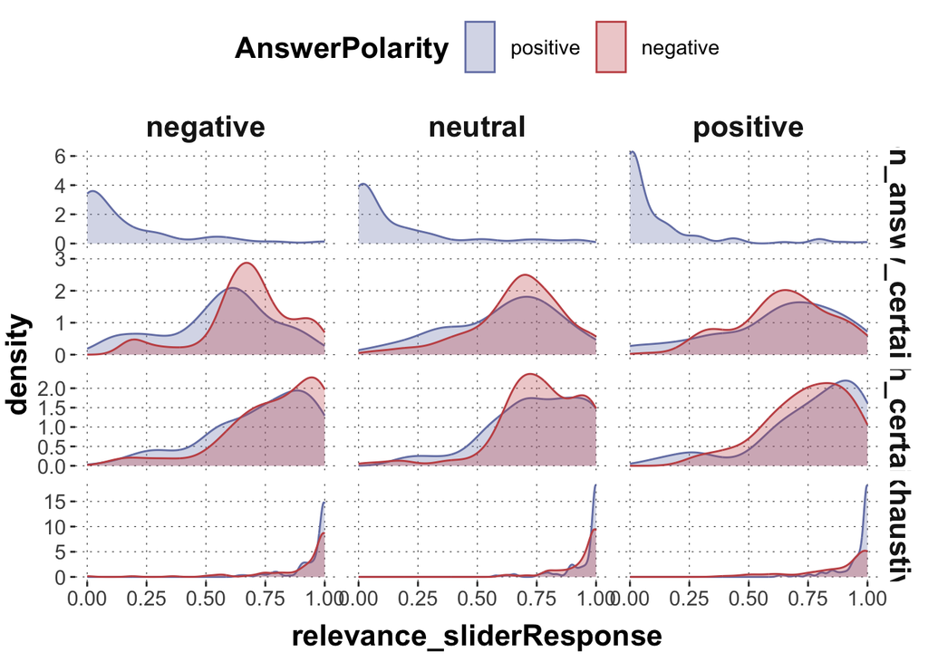

```r
d |>
  ggplot(aes(x = relevance_sliderResponse, color = AnswerPolarity, fill = AnswerPolarity)) +
  facet_grid(AnswerCertainty ~ ContextType , scales = "free") +
  geom_density(alpha = 0.3)
```

Let’s now look at a bunch of contrasts (based on the previously fitted full model).

```r
# fit_to_use = fit
fit_to_use = fit_without_group_ordBeta

## expected ordering relation?
## non-answers vs low-certainty => poster = 1
nonAns_VS_low  <- compare_groups(
  fit_to_use,
  lower  = AnswerCertainty == "non_answer",
  higher = AnswerCertainty == "low_certainty"
)
## low-certainty vs high-certainty => poster = 0.9922
low_VS_high <- compare_groups(
  fit_to_use,
  lower  = AnswerCertainty == "low_certainty",
  higher = AnswerCertainty == "high_certainty"
)
## high-certainty vs exhaustive => poster = 1
high_VS_exh <- compare_groups(
  fit_to_use,
  lower  = AnswerCertainty == "high_certainty",
  higher = AnswerCertainty == "exhaustive"
)


## effects of AnswerPolarity?
AnswerPolarity_main <- compare_groups(
  fit_to_use,
  lower  = AnswerPolarity == "positive" & AnswerCertainty != "non_answer",
  higher = AnswerPolarity == "negative" & AnswerCertainty != "non_answer"
)

AnswerPolarity_lowCertain <- compare_groups(
  fit_to_use,
  lower  = AnswerPolarity == "positive" & AnswerCertainty == "low_certainty",
  higher = AnswerPolarity == "negative" & AnswerCertainty == "low_certainty"
)

AnswerPolarity_highCertain <-compare_groups(
  fit_to_use,
  lower  = AnswerPolarity == "positive" & AnswerCertainty == "high_certainty",
  higher = AnswerPolarity == "negative" & AnswerCertainty == "high_certainty"
)

AnswerPolarity_exhaustive <-compare_groups(
  fit_to_use,
  lower  = AnswerPolarity == "positive" & AnswerCertainty == "exhaustive",
  higher = AnswerPolarity == "negative" & AnswerCertainty == "exhaustive"
)

ContextType_neutral_negative <-
  compare_groups(fit_to_use, higher = ContextType == "neutral", lower = ContextType == "negative")

ContextType_neutral_positive <-
  compare_groups(fit_to_use, higher = ContextType == "neutral", lower = ContextType == "positive")


cellComparisons <- tribble(
  ~comparison, ~posterior, ~"95%HDI (low)", ~"95%HDI (high)",
  "non-answer < low certainty" , nonAns_VS_low$post_prob, nonAns_VS_low$l_ci, nonAns_VS_low$u_ci,
  "low certain < high certain" , low_VS_high$post_prob, low_VS_high$l_ci, low_VS_high$u_ci,
  "high certain < exhaustive" , high_VS_exh$post_prob, high_VS_exh$l_ci, high_VS_exh$u_ci,
  "answer: pos < neg", AnswerPolarity_main$post_prob, AnswerPolarity_main$l_ci, AnswerPolarity_main$u_ci,
  # "Polarity (low certain)", AnswerPolarity_lowCertain$post_prob, AnswerPolarity_lowCertain$l_ci, AnswerPolarity_lowCertain$u_ci,
  # "Polarity (high certain)", AnswerPolarity_highCertain$post_prob, AnswerPolarity_highCertain$l_ci, AnswerPolarity_highCertain$u_ci,
  # "Polarity (exhaustive)", AnswerPolarity_exhaustive$post_prob, AnswerPolarity_exhaustive$l_ci, AnswerPolarity_exhaustive$u_ci,
  "context: neutral > pos", ContextType_neutral_positive$post_prob, ContextType_neutral_positive$l_ci, ContextType_neutral_positive$u_ci,
  "context: neutral > neg", ContextType_neutral_negative$post_prob, ContextType_neutral_negative$l_ci, ContextType_neutral_negative$u_ci
)

knitr::kable(cellComparisons)
```

| comparison | posterior | 95%HDI (low) | 95%HDI (high) |
| --- | --- | --- | --- |
| non-answer < low certainty | 1.00000 | 1.8158322 | 2.4952422 |
| low certain < high certain | 0.99850 | 0.2082523 | 0.9073744 |
| high certain < exhaustive | 1.00000 | 0.9603053 | 1.8931582 |
| answer: pos < neg | 0.42625 | -0.3057378 | 0.2491692 |
| context: neutral > pos | 0.97925 | -0.0037564 | 0.2987856 |
| context: neutral > neg | 0.87575 | -0.0603201 | 0.2136360 |

The table shows results indicating that there are (non-surprising) effects of `AnswerType` with non-answers rated as least relevant, followed by low-certainty, then high-certainty answers, and final exhaustive answers. There is no (strong) indication for a main effect of `AnswerPolarity` or `ContextType`. The lack of an effect of `ContextType` might be interpreted as *prima facie* evidence in favor of quantitative notions or relevance that do not take the prior into account (at least not very prominently).

Here is a plot of the relevant posterior draws visually supporting why we compared the three factor levels of `ContextType` in the way we did (`positive` is the lowest, `neutral` the highest, but this difference is still not strongly indicative of a difference (0 included in HDI)):

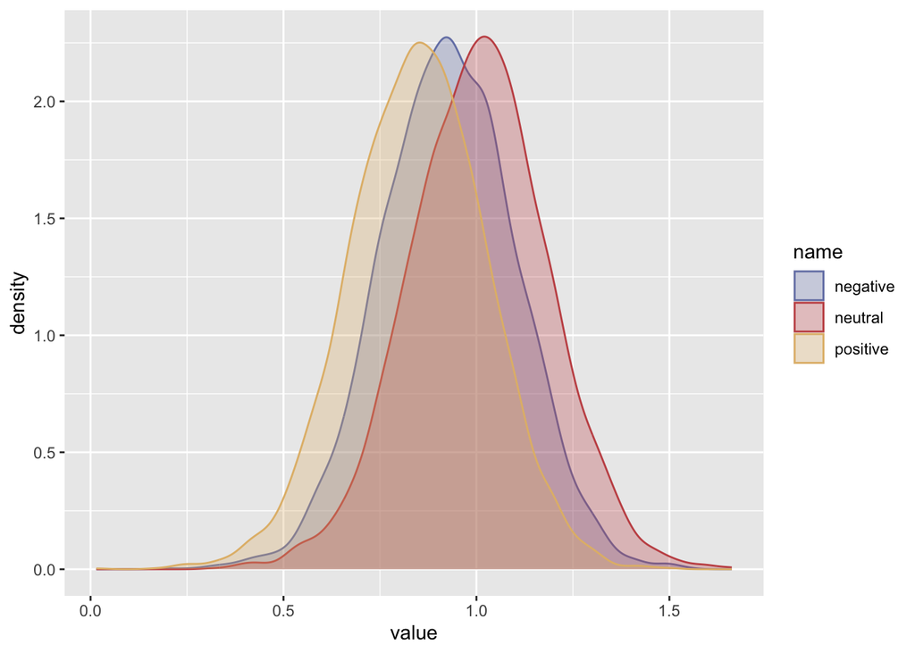

```r
draws_ContextType <-
  tibble(
    positive = extract_cell_draws(fit_to_use, ContextType == "positive", colname = "positive")$positive,
    negative = extract_cell_draws(fit_to_use, ContextType == "negative", colname = "negative")$negative,
    neutral  = extract_cell_draws(fit_to_use, ContextType == "neutral",  colname = "neutral" )$neutral
  ) |> pivot_longer(cols = everything())

draws_ContextType |>
  ggplot(aes(x = value, color = name, fill = name)) +
  geom_density(alpha = 0.3)
```

# Addressing the main research hypotheses

Research hypotheses 1 and 2 are basic predictions in terms of simple measures of first- and second-order belief change. Research hypothesis 3 is about different notions of quantifying informational relevance.

## Hypothesis 1: first-order belief change explains relevance ratings

The hypothesis is that higher belief changes (induced by the answer) lead to higher relevance ratings. We test this hypothesis by a linear beta regression model (with maximal random effects) that regresses relevance ratings against the absolute difference between prior and posterior ratings (`first_order_belief_change`). We judge there to be evidence in favor of this hypothesis if the relevant slope coefficient is estimated to be credibly bigger than zero (posterior probability > 0.944; an arbitrary value to indicate that there is nothing special about 0.95) and a loo-based model comparison with an intercept only model substantially favors the model that includes the relevant slope.

Run the regression model:

```r
if (rerun_models) {

  fit_belief_diff <- ordbetareg(
    formula = relevance_sliderResponse ~ first_order_belief_change +
      (1 + first_order_belief_change | submission_id) + (1 + first_order_belief_change | StimID),
    data = d
  )

  # TODO check how to run Intercept-only model in ordbetareg
  fit_belief_diff_interceptOnly <- ordbetareg(
    formula = relevance_sliderResponse ~  .,
    data = d |> mutate(Int = 1)
  )

  write_rds(fit_belief_diff, "cachedModels-round2/fit_belief_diff.rds")
  write_rds(fit_belief_diff_interceptOnly, "cachedModels-round2/fit_belief_diff_interceptOnly.rds")

} else {
  fit_belief_diff <- read_rds("cachedModels-round2/fit_belief_diff.rds")
  fit_belief_diff_interceptOnly <- read_rds("cachedModels-round2/fit_belief_diff_interceptOnly.rds")
}
```

Test hypothesis 1:

```r
brms::hypothesis(fit_belief_diff, "first_order_belief_change > 0")
```

```
Hypothesis Tests for class b:
                Hypothesis Estimate Est.Error CI.Lower CI.Upper Evid.Ratio
1 (first_order_beli... > 0     2.94      0.33     2.43     3.48        Inf
  Post.Prob Star
1         1    *
---
'CI': 90%-CI for one-sided and 95%-CI for two-sided hypotheses.
'*': For one-sided hypotheses, the posterior probability exceeds 95%;
for two-sided hypotheses, the value tested against lies outside the 95%-CI.
Posterior probabilities of point hypotheses assume equal prior probabilities.
```

```r
loo_comp_hyp1 <- loo_compare(list("w/__beliefDiff" = loo(fit_belief_diff),
                             "w/o_beliefDiff" = loo(fit_belief_diff_interceptOnly)))
loo_comp_hyp1
```

```
               elpd_diff se_diff
w/__beliefDiff     0.0       0.0
w/o_beliefDiff -2235.8      57.4
```

```r
# Lambert's z-score test
Lambert_test(loo_comp_hyp1)
```

```
[1] 0
```

We find support for hypothesis one.

## Hypothesis 2: confidence change additionally contributes to relevance rating

We also hypothesize that change in confidence (`second_order_belief_change`) ratings additionally contributes to predicting relevance ratings. Concretely, we address this hypothesis with a linear beta regression model like for hypothesis 1, but also including the absolute difference in confidence ratings for before and after the answer (and the interaction term). We use the maximal RE-structure. We speak of evidence in favor of this hypothesis if the relevant posterior slope parameter is credibly bigger than zero and a loo-based model comparison favors the more complex model. We speak of evidence against this hypothesis if the loo-based model comparison favors the simpler model.

Run the regression model:

```r
if (rerun_models) {

  fit_confidence_diff <- ordbetareg(
    formula = relevance_sliderResponse ~ first_order_belief_change * second_order_belief_change +
      (1 + first_order_belief_change * second_order_belief_change | submission_id) +
      (1 + first_order_belief_change * second_order_belief_change | StimID),
    data = d
  )

  write_rds(fit_confidence_diff, "cachedModels-round2/fit_confidence_diff.rds")

} else {
  fit_confidence_diff <- read_rds("cachedModels-round2/fit_confidence_diff.rds")
}
```

Test Hypothesis 2:

```r
brms::hypothesis(fit_confidence_diff, "second_order_belief_change > 0")
```

```
Hypothesis Tests for class b:
                Hypothesis Estimate Est.Error CI.Lower CI.Upper Evid.Ratio
1 (second_order_bel... > 0     0.32      0.05     0.23      0.4        Inf
  Post.Prob Star
1         1    *
---
'CI': 90%-CI for one-sided and 95%-CI for two-sided hypotheses.
'*': For one-sided hypotheses, the posterior probability exceeds 95%;
for two-sided hypotheses, the value tested against lies outside the 95%-CI.
Posterior probabilities of point hypotheses assume equal prior probabilities.
```

```r
loo_comp_hyp2 <- loo_compare(list("w/__confidence" = loo(fit_confidence_diff),
                             "w/o_confidence" = loo(fit_belief_diff)))
loo_comp_hyp2
```

```
               elpd_diff se_diff
w/__confidence   0.0       0.0
w/o_confidence -53.5      11.1
```

```r
# Lambert's z-score test
Lambert_test(loo_comp_hyp2)
```

```
[1] 0
```

We find support for hypothesis two.

## Hypothesis 3: “Bayes Factor utility” is the best single-factor predictor of relevance ratings

The third hypothesis is that the `bayes_factor_utility` is a better (single-factor, linear) predictor of `relevance_sliderResponse` than `kl_utility` and `entropy_change`. We address this hypothesis with LOO cross-validation. We also directly include the exploratory hypothesis 1 here, thus comparing *all* single-factor models.

```r
get_single_factor_formula <- function(factor) {
  # get formula for single factor with full RE structure
  brms::brmsformula(
    str_c("relevance_sliderResponse ~ (1 + ", factor, " | submission_id)",
    "+ (1 + ", factor, " | StimID) + ", factor))
}

if (rerun_models) {

  # ER
  fit_loo_ER <- ordbetareg(
    get_single_factor_formula("entropy_change"),
    iter = 6000,
    save_pars = save_pars(all = T),
    data = d,
    control = list(adapt_delta = 0.9)
  ) |> add_criterion("loo", model_name = "ER", moment_match = T)

  # KL
  fit_loo_KL <- ordbetareg(
    get_single_factor_formula("kl_utility"),
    iter = 6000,
    save_pars = save_pars(all = T),
    data = d,
    control = list(adapt_delta = 0.9)
  ) |> add_criterion("loo", model_name = "KL")

  # BF
  fit_loo_BF <- ordbetareg(
    get_single_factor_formula("bayes_factor_utility"),
    iter = 6000,
    save_pars = save_pars(all = T),
    data = d,
    control = list(adapt_delta = 0.9)
  ) |> add_criterion("loo", model_name = "BF")

  # ER_beta
  fit_loo_ER_beta <- ordbetareg(
    get_single_factor_formula("beta_entropy_change"),
    iter = 6000,
    save_pars = save_pars(all = T),
    data = d,
    control = list(adapt_delta = 0.9)
  ) |> add_criterion("loo", model_name = "ER_beta")

  # KL_beta
  fit_loo_KL_beta <- ordbetareg(
    get_single_factor_formula("beta_kl_utility"),
    iter = 6000,
    save_pars = save_pars(all = T),
    data = d,
    control = list(adapt_delta = 0.9)
  ) |> add_criterion("loo", model_name = "KL_beta")

  # BF_beta
  fit_loo_BF_beta <- ordbetareg(
    get_single_factor_formula("beta_bayes_factor_utility"),
    iter = 6000,
    save_pars = save_pars(all = T),
    data = d,
    control = list(adapt_delta = 0.9)
  ) |> add_criterion("loo", model_name = "BF_beta")

  # belief_diff
  fit_loo_belief_diff <- ordbetareg(
    get_single_factor_formula("first_order_belief_change"),
    iter = 6000,
    save_pars = save_pars(all = T),
    data = d,
    control = list(adapt_delta = 0.9)
  ) |> add_criterion("loo", model_name = "belief_diff")

  # confidence_diff
  fit_loo_confidence_diff <- ordbetareg(
    get_single_factor_formula("second_order_belief_change"),
    iter = 6000,
    save_pars = save_pars(all = T),
    data = d,
    control = list(adapt_delta = 0.9)
  ) |> add_criterion("loo", model_name = "confidence_diff")

  write_rds(fit_loo_ER, "cachedModels-round2/fit_loo_ER.rds")
  write_rds(fit_loo_KL, "cachedModels-round2/fit_loo_KL.rds")
  write_rds(fit_loo_BF, "cachedModels-round2/fit_loo_BF.rds")
  write_rds(fit_loo_ER_beta, "cachedModels-round2/fit_loo_ER_beta.rds")
  write_rds(fit_loo_KL_beta, "cachedModels-round2/fit_loo_KL_beta.rds")
  write_rds(fit_loo_BF_beta, "cachedModels-round2/fit_loo_BF_beta.rds")
  write_rds(fit_loo_belief_diff, "cachedModels-round2/fit_loo_belief_diff.rds")
  write_rds(fit_loo_confidence_diff, "cachedModels-round2/fit_loo_confidence_diff.rds")

} else{
  fit_loo_ER <- read_rds("cachedModels-round2/fit_loo_ER.rds")
  fit_loo_KL <- read_rds("cachedModels-round2/fit_loo_KL.rds")
  fit_loo_BF <- read_rds("cachedModels-round2/fit_loo_BF.rds")
  fit_loo_ER_beta <- read_rds("cachedModels-round2/fit_loo_ER_beta.rds")
  fit_loo_KL_beta <- read_rds("cachedModels-round2/fit_loo_KL_beta.rds")
  fit_loo_BF_beta <- read_rds("cachedModels-round2/fit_loo_BF_beta.rds")
  fit_loo_belief_diff <- read_rds("cachedModels-round2/fit_loo_belief_diff.rds")
  fit_loo_confidence_diff <- read_rds("cachedModels-round2/fit_loo_confidence_diff.rds")
}
```

LOO-based model comparison:

```r
loo_compare(
 fit_loo_ER,
 fit_loo_KL,
 fit_loo_BF,
 fit_loo_ER_beta,
 fit_loo_KL_beta,
 fit_loo_BF_beta,
 fit_loo_belief_diff,
 fit_loo_confidence_diff
)
```

```
                        elpd_diff se_diff
fit_loo_BF                 0.0       0.0
fit_loo_BF_beta         -168.2      37.0
fit_loo_ER              -179.4      29.6
fit_loo_KL_beta         -185.8      18.7
fit_loo_KL              -325.8      26.2
fit_loo_belief_diff     -357.9      29.6
fit_loo_confidence_diff -559.3      37.0
fit_loo_ER_beta         -695.1      37.8
```

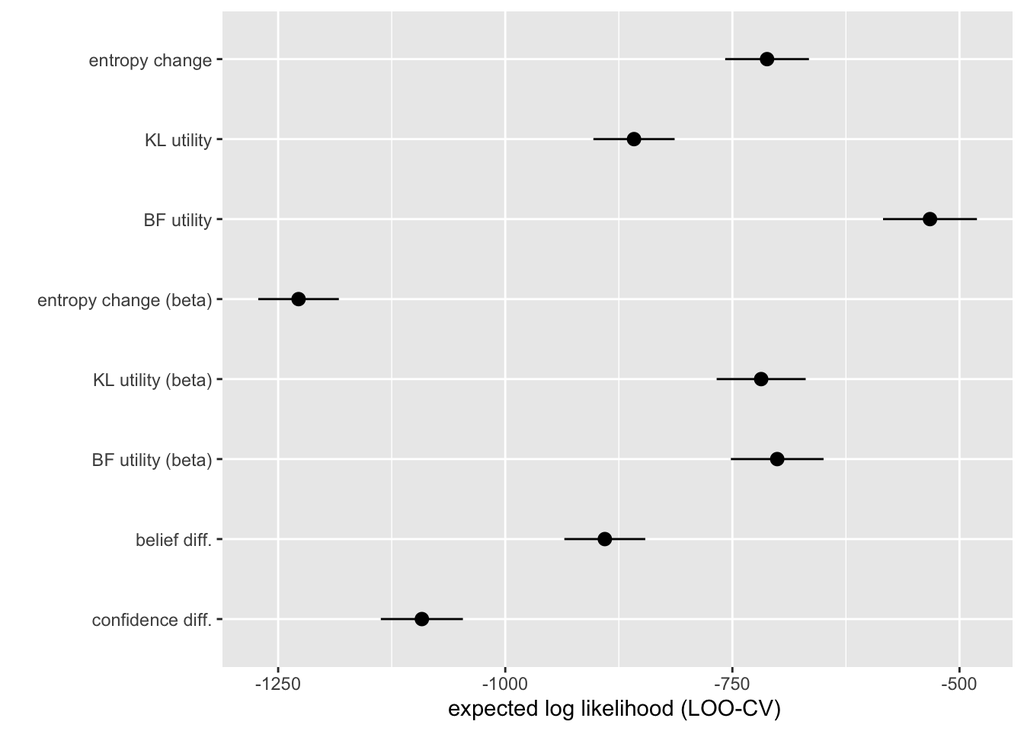

```r
model_names <- c("entropy change", "KL utility", "BF utility",
                 "entropy change (beta)", "KL utility (beta)", "BF utility (beta)",
                 "belief diff.", "confidence diff.")
tibble(
  model = factor(model_names, levels = rev(model_names)),
  ELPD  = c(
    loo(fit_loo_ER)$estimates['elpd_loo','Estimate'],
    loo(fit_loo_KL)$estimates['elpd_loo','Estimate'],
    loo(fit_loo_BF)$estimates['elpd_loo','Estimate'],
    loo(fit_loo_ER_beta)$estimates['elpd_loo','Estimate'],
    loo(fit_loo_KL_beta)$estimates['elpd_loo','Estimate'],
    loo(fit_loo_BF_beta)$estimates['elpd_loo','Estimate'],
    loo(fit_loo_belief_diff)$estimates['elpd_loo','Estimate'],
    loo(fit_loo_confidence_diff)$estimates['elpd_loo','Estimate']
  ),
  SE = c(
    loo(fit_loo_ER)$estimates['elpd_loo','SE'],
    loo(fit_loo_KL)$estimates['elpd_loo','SE'],
    loo(fit_loo_BF)$estimates['elpd_loo','SE'],
    loo(fit_loo_ER_beta)$estimates['elpd_loo','SE'],
    loo(fit_loo_KL_beta)$estimates['elpd_loo','SE'],
    loo(fit_loo_BF_beta)$estimates['elpd_loo','SE'],
    loo(fit_loo_belief_diff)$estimates['elpd_loo','SE'],
    loo(fit_loo_confidence_diff)$estimates['elpd_loo','SE']
  ),
  lower = ELPD - SE,
  upper = ELPD + SE
) |>
  ggplot(aes( x = model , y = ELPD)) +
  geom_pointrange(aes(min = lower, max = upper)) +
  coord_flip() +
  xlab("") +
  ylab("expected log likelihood (LOO-CV) ")
```

Testing whether there is a substantial difference between the two best models:

```r
loo_comp <- loo_compare(fit_loo_BF, fit_loo_BF_beta)
loo_comp
```

```
                elpd_diff se_diff
fit_loo_BF         0.0       0.0
fit_loo_BF_beta -168.2      37.0
```

```r
Lambert_test(loo_comp)
```

```
[1] 0
```

Testing whether there is a substantial difference between the first and the third best model:

```r
loo_comp <- loo_compare(fit_loo_BF, fit_loo_ER)
loo_comp
```

```
           elpd_diff se_diff
fit_loo_BF    0.0       0.0
fit_loo_ER -179.4      29.6
```

```r
Lambert_test(loo_comp)
```

```
[1] 0
```

Yes, these are substantially different.

We can conclude that first-order BF is the single best predictor of the relevance ratings.

# Addressing the exploratory hypotheses

## Exploratory Hypothesis 2: adding `pure_second_order_belief_change` to all first-order measures

To complement hypothesis 2, we also test whether adding another measure of higher-order uncertainty change adds predictive performance to each first-order measure of belief change. So here we compare, for each measure $X$ (“entropy change”, “KL”, and “Bayes factor”) for first-order belief change, whether adding the factor `pure_second_order_belief_change` increases the predictive performance. Concretely, we compare a model with single factor $X$ as a predictor to a model with predictors $X$, `pure_second_order_belief_change` and teir interaction. For ease of fitting, no random effects are included.

First, run the relevant models.

```r
get_formula_two_factors <- function(factor1, factor2) {
  # brms::brmsformula(
  #   str_c(
  #     "relevance_sliderResponse ~ (1 + ", factor1, " + " ,  factor2, " | submission_id)",
  #     "+ (1 + ", factor1, " + " , factor2, " | StimID) + ",
  #     factor1, " * ", factor2))
  if (factor2 == "") {
    brms::brmsformula(
      str_c(
        "relevance_sliderResponse ~ ", factor1))
  } else {
    brms::brmsformula(
    str_c(
      "relevance_sliderResponse ~ ", factor1, " * " ,  factor2))
  }
}

# get_formula_two_factors("X", "Y")
# get_formula_two_factors("X", "")

fit_model_two_factors <- function(name, factor1, factor2) {
  filename <- paste0(c("cachedModels-round2/", name, ".rds"), collapse = "")
  if (rerun_models) {
    x <- ordbetareg(
      get_formula_two_factors(factor1, factor2),
      iter = 2000,
      save_pars = save_pars(all = T),
      data = d,
      control = list(adapt_delta = 0.9)
    ) |> add_criterion("loo", model_name = name, moment_match = T)
    write_rds(x, filename)
    return(x)
  } else{
    read_rds(filename)
  }

}

# ER
fit_expHyp2_ER <- fit_model_two_factors(
  "fit_expHyp2_ER",
  "entropy_change",
  "")
fit_expHyp2_ER_pure <- fit_model_two_factors(
  "fit_expHyp2_ER_pure",
  "entropy_change",
  "pure_second_order_belief_change")


#KL
fit_expHyp2_KL <- fit_model_two_factors(
  "fit_expHyp2_KL",
  "kl_utility",
  "")
fit_expHyp2_KL_pure <- fit_model_two_factors(
  "fit_expHyp2_KL_pure",
  "kl_utility",
  "pure_second_order_belief_change")


#BF
fit_expHyp2_BF <- fit_model_two_factors(
  "fit_expHyp2_BF",
  "bayes_factor_utility",
  "")
fit_expHyp2_BF_pure <- fit_model_two_factors(
  "fit_expHyp2_BF_pure",
  "bayes_factor_utility",
  "pure_second_order_belief_change")
```

Then compare the relevant pairs with LOO:

```r
loo_compare(fit_expHyp2_ER, fit_expHyp2_ER_pure)
```

```
                    elpd_diff se_diff
fit_expHyp2_ER_pure   0.0       0.0
fit_expHyp2_ER      -63.7      11.8
```

```r
loo_compare(fit_expHyp2_KL, fit_expHyp2_KL_pure)
```

```
                    elpd_diff se_diff
fit_expHyp2_KL_pure    0.0       0.0
fit_expHyp2_KL      -168.4      18.6
```

```r
loo_compare(fit_expHyp2_BF, fit_expHyp2_BF_pure)
```

```
                    elpd_diff se_diff
fit_expHyp2_BF_pure   0.0       0.0
fit_expHyp2_BF      -85.1      11.8
```

It appears that for all three measures of first-order belief change, adding `pure_second_order_belief_change` yields a substantially better model.

## Exploratory Hypothesis 3: compare all combinations of first- and second-order measures

Finally, we just compare models with all combinations of first- and second-order measures. Questions of interest are:

1. Which arbitrary combination of first- and second-order measures is the best?
2. Does it matter to be consistent in the choice of first- and second order measure, i.e., is the performance of “first-order X” always most boosted when we supply it with “second-order X” instead of some other “second-order Y”?

Let’s run the models first. For ease of fitting, no random effects are included.

```r
# base-level: ER

fit_loo_ER_ER <- fit_model_two_factors(
  "fit_loo_ER_ER",  "entropy_change",  "beta_entropy_change")

fit_loo_ER_KL <- fit_model_two_factors(
  "fit_loo_ER_KL",  "entropy_change",  "beta_kl_utility")

fit_loo_ER_BF <- fit_model_two_factors(
  "fit_loo_ER_BF",  "entropy_change",  "beta_bayes_factor_utility")

# base-level: KL

fit_loo_KL_ER <- fit_model_two_factors(
  "fit_loo_KL_ER",  "kl_utility",  "beta_entropy_change")

fit_loo_KL_KL <- fit_model_two_factors(
  "fit_loo_KL_KL",  "kl_utility",  "beta_kl_utility")

fit_loo_KL_BF <- fit_model_two_factors(
  "fit_loo_KL_BF",  "kl_utility",  "beta_bayes_factor_utility")

# base-level: BF

fit_loo_BF_ER <- fit_model_two_factors(
  "fit_loo_BF_ER",  "bayes_factor_utility",  "beta_entropy_change")

fit_loo_BF_KL <- fit_model_two_factors(
  "fit_loo_BF_KL",  "bayes_factor_utility",  "beta_kl_utility")

fit_loo_BF_BF <- fit_model_two_factors(
  "fit_loo_BF_BF",  "bayes_factor_utility",  "beta_bayes_factor_utility")
```

Compare all models.

```r
loo_compare(
 fit_loo_ER_ER,
 fit_loo_ER_KL,
 fit_loo_ER_BF,
 fit_loo_KL_ER,
 fit_loo_KL_KL,
 fit_loo_KL_BF,
 fit_loo_BF_ER,
 fit_loo_BF_KL,
 fit_loo_BF_BF
)
```

```
              elpd_diff se_diff
fit_loo_BF_BF    0.0       0.0
fit_loo_ER_BF -103.2      21.6
fit_loo_BF_ER -122.9      15.3
fit_loo_BF_KL -124.3      15.6
fit_loo_ER_KL -136.3      19.3
fit_loo_KL_BF -171.6      19.3
fit_loo_KL_KL -267.1      18.6
fit_loo_ER_ER -302.1      31.4
fit_loo_KL_ER -450.7      30.1
```

Plot results.

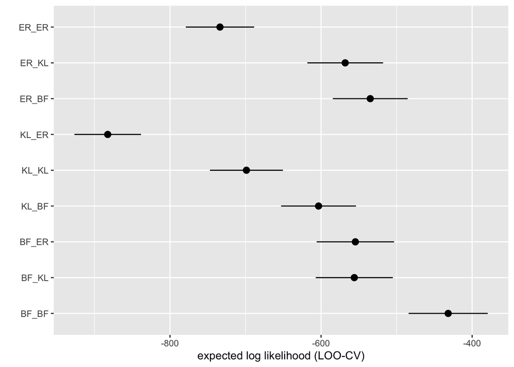

```r
model_names <- c("ER_ER", "ER_KL", "ER_BF",
  "KL_ER", "KL_KL", "KL_BF",
  "BF_ER", "BF_KL", "BF_BF")

tibble(
  model = factor(model_names, levels = rev(model_names)),
  ELPD  = c(
    loo(fit_loo_ER_ER)$estimates['elpd_loo', 'Estimate'],
    loo(fit_loo_ER_KL)$estimates['elpd_loo', 'Estimate'],
    loo(fit_loo_ER_BF)$estimates['elpd_loo', 'Estimate'],
    loo(fit_loo_KL_ER)$estimates['elpd_loo', 'Estimate'],
    loo(fit_loo_KL_KL)$estimates['elpd_loo', 'Estimate'],
    loo(fit_loo_KL_BF)$estimates['elpd_loo', 'Estimate'],
    loo(fit_loo_BF_ER)$estimates['elpd_loo', 'Estimate'],
    loo(fit_loo_BF_KL)$estimates['elpd_loo', 'Estimate'],
    loo(fit_loo_BF_BF)$estimates['elpd_loo', 'Estimate']
  ),
  SE = c(
    loo(fit_loo_ER_ER)$estimates['elpd_loo', 'SE'],
    loo(fit_loo_ER_KL)$estimates['elpd_loo', 'SE'],
    loo(fit_loo_ER_BF)$estimates['elpd_loo', 'SE'],
    loo(fit_loo_KL_ER)$estimates['elpd_loo', 'SE'],
    loo(fit_loo_KL_KL)$estimates['elpd_loo', 'SE'],
    loo(fit_loo_KL_BF)$estimates['elpd_loo', 'SE'],
    loo(fit_loo_BF_ER)$estimates['elpd_loo', 'SE'],
    loo(fit_loo_BF_KL)$estimates['elpd_loo', 'SE'],
    loo(fit_loo_BF_BF)$estimates['elpd_loo', 'SE']
  ),
  lower = ELPD - SE,
  upper = ELPD + SE
) |>
  ggplot(aes( x = model , y = ELPD)) +
  geom_pointrange(aes(min = lower, max = upper)) +
  coord_flip() +
  xlab("") +
  ylab("expected log likelihood (LOO-CV)")
```

It seems that the overall best model in this comparison is the one that uses Bayes-factor based measures consistently. The second-order Bayes-factor based measure also seems to be the best to add to the other first-order measures. This also means that it is not the case the “being consisten” in choic of first- and second-order measure is always best.